# Week 4: Conceptual Exercise

Andrew Eckert (worked example)

Helene Wagner (vignette)

2017-11-12

## Introduction

### a) Goals

**Motivation**: Natural selection acts on phenotypic variation that is genetically determined. As such, it can be difficult to get a complete picture about adaptation from scanning genomes using molecular markers. The reason is that genetic outliers, even if true positives, have little to no information present about what phenotype they affect and how this phenotype results in fitness differences. Moreover, it is debatable to scan genomes for the presence of outliers if you have yet to demonstrate that the populations being sampled are locally adapted.

**Learning Objectives**: This assignment focuses on the interpretation of basic quantitative and population genetic analyses useful to testing hypotheses about local adaptation. Phenotypic measurement is undergoing a revolution, so that familiarity with basic methods in quantitative genetics will serve you well in the future.

In addition, this week’s worked example (computer lab) shows how to run the analyses to generate the output shown here.

### b) Data set

The data come from a study of western white pine (*Pinus monticola* Dougl. ex D. Don) sampled around the Lake Tahoe Basin of California and Nevada. These data consist of 157 trees sampled from 10 populations (n = 9 to 22 trees/population). Within each population, trees were sampled within three plots. For each plot, GPS coordinates were collected (i.e. each plot in each population has its own GPS coordinates) and used to generate a set of 7 environmental variables. From these trees, needle tissue was collected from which total DNA was extracted and genotyped for 164 single nucleotide polymorphisms (SNPs). Seeds were also collected and planted in a common garden. The seedlings (n = 5 to 35/tree) were measured for several phenotypic traits.

The phenotypic trait we will be working with today is known as the carbon isotope ratio ($δ^{13}C$). It is the ratio of two isotopes of carbon ($^{13}C$ and $^{12}C$) relative to an experimental control, and it is strongly correlated with intrinsic water-use efficiency in plants. Plants need water to live, so it is not a stretch of the imagination to believe that this phenotypic trait has a link with plant fitness.

We thus have three types of data:

- Phenotypic measurements for 5 seedlings per tree made in a common garden.
- Environmental data collected from each plot within each population.
- SNP genotypes for all 157 trees sampled in the field

## Part 1: Estimate genetic values for an observed phenotypic trait

**Motivation**: A lot of genetics can be carried out without use of any molecular markers. Practitioners of empirical population genetics forget this quite often. A common garden allows us to create a standardized environment in which we minimize the influence of environment on the expression of a particular phenotypic trait. Since we know, after over a century of showing it to be true, that phenotypic variation results from genetic variation, environmental variation, and the interaction of genetic and environmental variation, then if we standardize the environment, phenotypic variation we see in the common garden is due to genetic variation (or if multiple gardens are used, genetics and the interaction of genetics and the environment).

**Goals**: The goal for this part is to model $δ^{13}C$ measurements of seedlings as a combined effect of family (mother tree) and population (where mothers are nested within populations). Also included is an experimental treatment known as “block”. In a common garden, seedlings from the same maternal tree are randomized among blocks to avoid the influence of micro-environmental variation on expression of phenotypic traits.

We will compare three models (all models include a fixed effect of block):

- **Model 1**: a fixed effect model with only an intercept,
- **Model 2**: a LMM (linear mixed model) with an intercept (fixed) and a random effect due to family, and
- **Model 3**: a LMM with an intercept, a random effect due to family nested within population, and a random effect of population.

```r
mod1<- lm(phen$d13c~1+phen$block)
mod2<- lmer(d13c~1+(1|family)+block,data = phen, REML = F)
mod3 <- lmer(d13c ~ 1 + (1|population/family) + block, data = phen, REML = F)
```

**Question 1**: *Compare the output for the three models below. What do you conclude about the effect of block in each of the models? Remember this is an experimental treatment, so your conclusion directly addresses whether micro-environmental variation exists in your common garden.*

```
##
##  Model 1:
```

```
## Anova Table (Type III tests)
##
## Response: phen$d13c
##             Sum Sq  Df    F value    Pr(>F)
## (Intercept) 132026   1 148103.913 < 2.2e-16 ***
## phen$block       9   1     10.609  0.001175 **
## Residuals      693 777
## ---
## Signif. codes:  0 '***' 0.001 '**' 0.01 '*' 0.05 '.' 0.1 ' ' 1
```

```
##
##  Model 2:
```

```
## Analysis of Deviance Table (Type III Wald chisquare tests)
##
## Response: d13c
##                 Chisq Df Pr(>Chisq)
## (Intercept) 150694.12  1  < 2.2e-16 ***
## block           12.12  1  0.0004987 ***
## ---
## Signif. codes:  0 '***' 0.001 '**' 0.01 '*' 0.05 '.' 0.1 ' ' 1
```

```
##
##  Model 3:
```

```
## Analysis of Deviance Table (Type III Wald chisquare tests)
##
## Response: d13c
##                 Chisq Df Pr(>Chisq)
## (Intercept) 61232.571  1  < 2.2e-16 ***
## block          11.816  1  0.0005874 ***
## ---
## Signif. codes:  0 '***' 0.001 '**' 0.01 '*' 0.05 '.' 0.1 ' ' 1
```

Now, let’s explore which model best fits our data. To do this we will use the Akaike Information Criterion (AIC). This statistic is like a penalized likelihood score, where the penalty increases as the number of parameters in a model increases. When using AIC, the model with the lowest score is the preferred model.

```
##
##  AIC values:
```

```
##     mod1     mod2     mod3
## 2125.188 2086.747 2057.946
```

**Question 2**: *Which model fits the data best?*

We can express the relative support of each model using Akaike weights. They add to one and can be thought of as conditional probabilities of each model, with the conditioning being on only these three models being examined.

```
##
##  Akaike weights:
```

```
## [1] 2.504603e-15 5.571182e-07 9.999994e-01
```

**Question 3**:

- *Which model has the highest probability?*
- *How much larger is it than the other probabilities?*
- *What does this tell you about your optimal model?*

## Part 2: Estimate trait heritability

**Motivation**: Once we have estimated genetic values for $δ^{13}C$ with the best model from above, we can estimate what fraction of the total variation in trait values is due to genetic effects and how much of this genetic effect is due to families nested within populations and to populations. These analyses provide key information about whether or not local adaptation should even be considered. Remember that local adaptation is about genetically determined phenotypes that vary across environments in responses to differing selective pressures. This step allows us to assess how genetic variation for a phenotypic trait is distributed across the landscape.

**Goals**: The goal for this part is to estimate heritability, trait differentiation, and correlation with environment for trait values determined in Part 1.

### a) Heritability

Let’s start with estimating the heritability of $δ^{13}C$. If you remember from your undergraduate evolution course, heritability refers generally to the proportion of phenotypic variance due to genetic variance. It comes in at least two different versions. The version we are interested in is narrow-sense heritability ($h^2$), which is defined as the ratio of additive genetic variance to total phenotypic variance:

$$h^{2} = \frac{\sigma^{2}_{additive}}{\sigma^{2}_{total}}$$

If we assume that the seedlings from each maternal tree are half-siblings (i.e. same mom, but each with a different father) then $σ^2_{additive} = 4 σ^2_{family}$ (so variance due to family:population). If the seedlings were all full-siblings, then the 4 would be replaced with 2.

```
##
##  Estimate of h^2:
```

```
## [1] 0.3986469
```

**Question 4**: *What does this value mean?*

```
##
##  95% bootstrap confidence interval:
```

```
##      2.5%       50%     97.5%
## 0.1363404 0.3948233 0.6678929
```

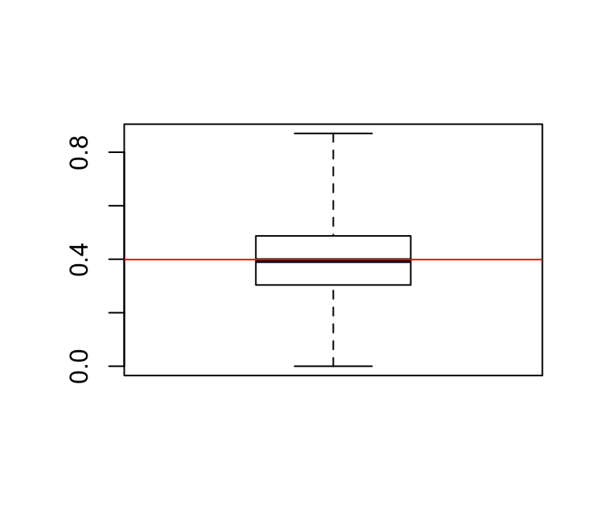

Compare the numerical 95% confidence interval and boxplot with our original estimate of $h^2= 0.399$ (red line).

**Question 5**:

- *Do you think that $h^2$ is statistically different than zero?*
- *Is this consistent with the AIC results from Part 1?*
- *Is it meaningful that the red line is very similar to the mean (or median) of the bootstrap distribution?*

### b) Trait differentiation

Great, we have shown that within population genetic variation is statistically greater than zero. What about among population genetic variation? Let’s get to that right now. To measure among population genetic variation we will use a statistic known as $Q_{ST}$. It is similar in concept to $F_{ST}$ from population genetics. If we assume that all seedlings are again half-siblings, then:

$$Q_{ST} = \frac{\sigma^{2}_{population}}
{\sigma^{2}_{population}+8\sigma^{2}_{family}}$$

```
##
##  Estimate of QST:
```

```
## [1] 0.1294699
```

**Question 6**:

- *What does this value mean?*
- *Look at the quantities in the equation above, what is the denominator equal to?*
- *Is it the total phenotypic variance or the total genetic variance?*

Now, we can again look at a confidence interval using parametric bootstrapping.

```
##
##  95% bootstrap confidence interval:
```

```
##       2.5%        50%      97.5%
## 0.01936753 0.10610589 0.32138221
```

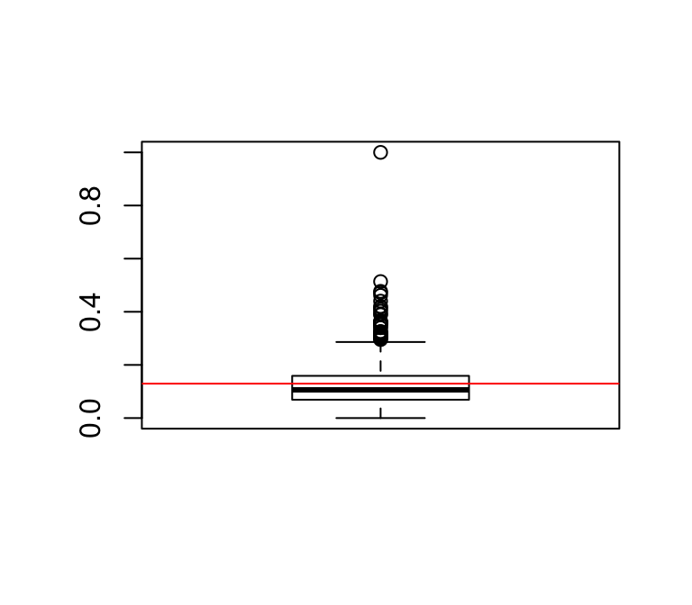

**Question 7**: Interpret the results.

- *Do you think that $Q_{ST}$ is statistically different than zero?*
- *Is this consistent with the AIC results from Part 1?*
- *Is it meaningful that the red line is less similar to the mean (or median) of the bootstrap distribution as compared to $h^2$?*

### c) Trait correlation with environment

Finally, let’s test for correlations between genetic values of $δ^{13}C$ and environmental data. The output below shows the correlation matrix for trait $δ^{13}C$, spatial coordinates (longitude, latitude) and the following bioclimatic variables:

- **max_rad**: maximum solar radiation
- **tmax_july**: July maximum temperature
- **tmin_jan**: January minimum temperature
- **ann_ppt**: annual precipitation
- **gdd_aug**: growing degree days in August (i.e, temperature > 10C)
- **AWS050**: available water supply (soil property)

```
##            d13c longitude latitude  elev max_rad tmax_july tmin_jan
## d13c       1.00      0.00     0.36 -0.32    0.21      0.07     0.15
## longitude  0.00      1.00    -0.03  0.58    0.09     -0.15    -0.44
## latitude   0.36     -0.03     1.00 -0.32   -0.05      0.47     0.36
## elev      -0.32      0.58    -0.32  1.00    0.32     -0.69    -0.82
## max_rad    0.21      0.09    -0.05  0.32    1.00     -0.41    -0.22
## tmax_july  0.07     -0.15     0.47 -0.69   -0.41      1.00     0.70
## tmin_jan   0.15     -0.44     0.36 -0.82   -0.22      0.70     1.00
## ann_ppt    0.22     -0.49    -0.08  0.06    0.48     -0.59    -0.06
## gdd_aug    0.39      0.15     0.21 -0.58   -0.19      0.61     0.69
## AWS050    -0.07     -0.40     0.36 -0.43   -0.12      0.60     0.46
##           ann_ppt gdd_aug AWS050
## d13c         0.22    0.39  -0.07
## longitude   -0.49    0.15  -0.40
## latitude    -0.08    0.21   0.36
## elev         0.06   -0.58  -0.43
## max_rad      0.48   -0.19  -0.12
## tmax_july   -0.59    0.61   0.60
## tmin_jan    -0.06    0.69   0.46
## ann_ppt      1.00   -0.28  -0.13
## gdd_aug     -0.28    1.00   0.07
## AWS050      -0.13    0.07   1.00
```

**Question 8**:

- *Which site variables show the strongest correlation with the trait?*
- *Which site variables are strongly correlated with each other?*

The multiple regression model below shows us the effect of each variable on $δ^{13}C$, given all other variables in the model. Because the environmental variables were standardized, we can directly compare their effects from the slope estimates.

```
##
## Call:
## lm(formula = d13c ~ longitude + latitude + elev + max_rad + tmax_july +
##     tmin_jan + ann_ppt + gdd_aug + AWS050, data = phen_env)
##
## Residuals:
##      Min       1Q   Median       3Q      Max
## -1.53330 -0.47104 -0.03884  0.35799  1.84054
##
## Coefficients:
##               Estimate Std. Error t value Pr(>|t|)
## (Intercept)  1.545e-14  5.122e-02   0.000 1.000000
## longitude   -5.314e-01  2.506e-01  -2.121 0.035601 *
## latitude     6.100e-01  9.506e-02   6.418 1.79e-09 ***
## elev        -5.179e-01  1.609e-01  -3.218 0.001586 **
## max_rad      2.839e-01  7.081e-02   4.009 9.66e-05 ***
## tmax_july   -8.850e-01  2.514e-01  -3.520 0.000575 ***
## tmin_jan    -9.526e-01  1.350e-01  -7.058 6.20e-11 ***
## ann_ppt     -3.330e-01  2.181e-01  -1.527 0.128891
## gdd_aug      1.188e+00  2.224e-01   5.341 3.44e-07 ***
## AWS050       1.570e-01  8.988e-02   1.747 0.082802 .
## ---
## Signif. codes:  0 '***' 0.001 '**' 0.01 '*' 0.05 '.' 0.1 ' ' 1
##
## Residual standard error: 0.6418 on 147 degrees of freedom
## Multiple R-squared:  0.6118, Adjusted R-squared:  0.5881
## F-statistic: 25.75 on 9 and 147 DF,  p-value: < 2.2e-16
```

These estimates and p-values are based on type II sums of squares. This means that for each predictor, they are estimated as if it was added last to the model, thus accounting for the effect of all other variables in the model. As a result, the estimated slope coefficients ‘Estimate’, and their p-values ‘Pr(>|t|)’ may differ from the results of a simple regression analysis (with a single predictor in each model) due to the correlation among predictor variables.

**Question 9**:

- *Is this multiple regression model statistically significant? If so, why?*
- *Which variables have a statistically significant association with the trait, given all other variables in the model?*
- *Which variables have the strongest association (use the column labeled ‘Estimate’, which is the partial regression coefficient)? Is this consistent with the correlation results?*

What is the relative contribution of climate vs. geography to variation in the trait $δ^{13}C$? This can be assessed with variation partitioning:

```
##
## Partition of variance in RDA
##
## Call: vegan::varpart(Y = WWP@P$d13c, X = WWP@E, WWP@XY, transfo =
## "standardize")
## Species transformation:  standardize
## Explanatory tables:
## X1:  WWP@E
## X2:  WWP@XY
##
## No. of explanatory tables: 2
## Total variation (SS): 156
##             Variance: 1
## No. of observations: 157
##
## Partition table:
##                      Df R.squared Adj.R.squared Testable
## [a+b] = X1            7   0.45828       0.43283     TRUE
## [b+c] = X2            2   0.12886       0.11755     TRUE
## [a+b+c] = X1+X2       9   0.61184       0.58808     TRUE
## Individual fractions
## [a] = X1|X2           7                 0.47053     TRUE
## [b]                   0                -0.03770    FALSE
## [c] = X2|X1           2                 0.15525     TRUE
## [d] = Residuals                         0.41192    FALSE
## ---
## Use function 'rda' to test significance of fractions of interest
```

The partition table lists the size of different fractions of variance. Interpretation should be based on adjusted $R^2$ values. Note that negative $R^2$ values should be interpreted as zero.

- **[a+b]**: percent of variance in trait that can be explained by climate.
- **[b+c]**: percent of variance explained by geography.
- **[a+b+c]**: percent of variance explained by climate and/or geography.
- **[a]**: percent of variance explained only by climate, unrelated to geography.
- **[b]**: percent of variance shared by climate and geography.
- **[a]**: percent of variance explained only by geography, unrelated to climate.

The figure is a graphical representation of the fractions. Here, X1 is the set of bioclimatic variables (‘climate’), and X2 is the spatial coordinates (‘geography’).

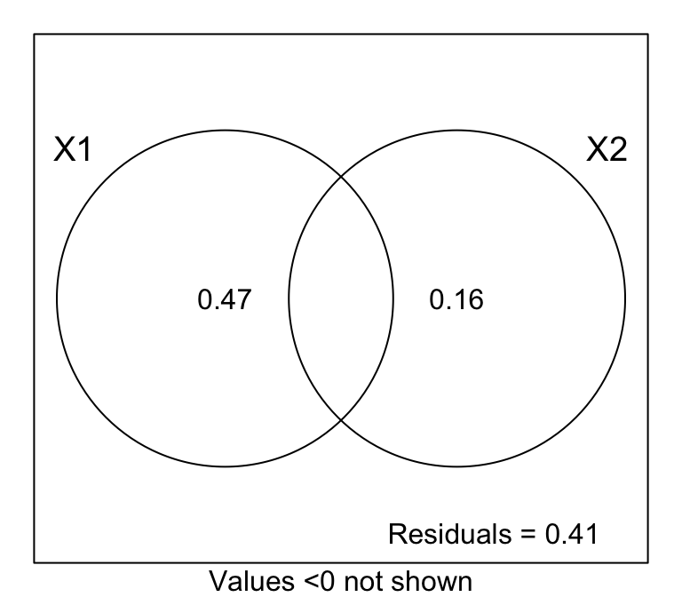

**Question 10**: Interpret the partition table and the figure.

- *How much of the variance in trait $δ^{13}C$ can be explained by climate and geography, in total? Do you think this is a large effect or not? Why?*
- *What is the relative importance of climate vs. geography?*
- *What does geography represent biologically?*
- *To what degree are climate and geography confounded in this example?*

## Part 4: Compare $Q_{ST}$ to $F_{ST}$

**Motivation**: Now that we have shown that genetic variation for $δ^{13}C$ within populations is significantly greater than zero (i.e. $h^2 > 0$), that differentiation for $δ^{13}C$ is statistically greater than zero (i.e. $Q_{ST} > 0$), and that climate, and to a lesser degree geography, is correlated with $δ^{13}C$ values, we can formally test whether or not differentiation for $δ^{13}C$ is unexplainable due to neutral processes such as genetic drift and gene flow.

The general idea is use a set of genetic markers we think primarily reflects neutral processes to estimate what $Q_{ST}$ should be without any form of natural selection operating in our system. To do that, we will use 164 SNPs sampled from gene regions that have no apparent functional connection to $δ^{13}C$. This will allow us to conclude that the differentiation we see is not just different from zero (done before), but different than expectations from a neutral model.

**Goals**: The goal for this part of the laboratory is to test the hypothesis that $Q_{ST}$ is greater than $F_{ST}$.

### a) Estimate $F_{ST}$ from SNP data

Let’s examine differentiation for the SNP data using FST.

```
##              Pop        Ind
## Total 0.01419871 0.04498675
## Pop   0.00000000 0.03123149
```

Here is a matrix of F-statistics. These work by using as subscripts the column title relative to the row title, so the first value on the first line is the F- statistic for population relative to total (i.e. $F_{ST}$). It is calculated based on the variance components from $overall as:

$$F_{pop,tot} = \frac{\sigma^{2}_{pop}}
{\sigma^{2}_{pop}+\sigma^{2}_{ind}+\sigma^{2}_{error}}$$

We can calculate $F_{ST}$ for each SNP and plot it against heterozygosity (left). Or to make a plot like those from Arlequin, we divide the heterozygosity values by $(1-F_{ST})$ prior to plotting them (right).

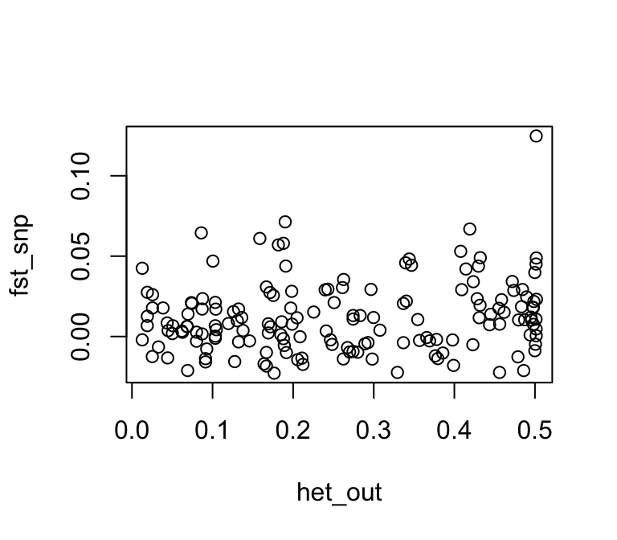

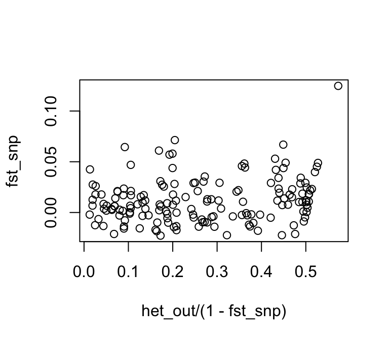

**Question 11**:

- *Do any SNPs show an unusual $F_{ST}$ value?*
- *If so, what could this mean?*

### b) Compare $Q_{ST}$ to $F_{ST}$

Now that we have inspected overall genetic differentiation among populations, let’s test whether or not $Q_{ST} > F_{ST}$ for $δ^{13}C$. The output below lists three p-values, each corresponding to a different alternative hypothesis $H_A$:

- Lower one-tailed: $H_A: Q_{ST} < F_{ST}$
- Upper one-tailed: $H_A: Q_{ST} > F_{ST}$
- Two-tailed: $H_A: Q_{ST} - F_{ST}$

```
## Lower one-tailed p value Upper one-tailed p value       Two-tailed p value
##                   0.9938                   0.0062                   0.0124
```

**Question 12**:

- *Is $Q_{ST} > F_{ST}$?*
- *What does this mean biologically?*